# モジュラリティ最大化に基づくコミュニティ抽出（コミュニティの重複を考慮しない場合）

代謝ネットワークの一部（解糖系・糖新生とTCA回路）を例にして，コミュニティ検出を行います。

```r
# パッケージの読み込み
library(igraph)
```

### ネットワークの読み込み

```r
# エッジリスト形式のネットワークデータを読み込む
d <- read.table("../data/eco_EM+TCA.txt")
# 無向ネットワークで読み込む
g <- graph_from_data_frame(d, directed=F)
# 多重エッジや自己ループを削除する。
g <- simplify(g, remove.multiple=T, remove.loops=T)
```

### 貪欲アルゴリズムに基づく方法

```r
# アルゴリズムの実行
data <- cluster_fast_greedy(g)
# メンバーシップの表示
data$membership
```

```
 [1] 4 1 1 5 2 2 1 5 2 1 2 3 2 2 1 1 4 3 5 4 5 5 2 2 3 3 4
```

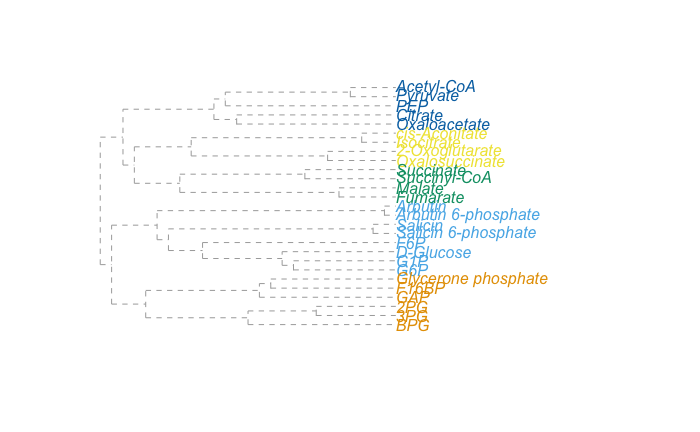

```r
# デンドログラムの表示
plot_dendrogram(data)
```

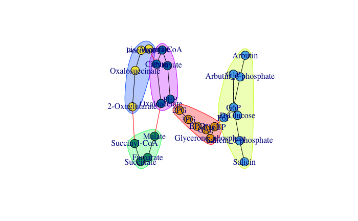

```r
# コミュニティ検出の結果
set.seed(5)
plot(data, g)
```

### スペクトル法（固有ベクトルに基づく方法）に基づく方法

```r
# アルゴリズムの実行
data <- cluster_leading_eigen(g,options=list(maxiter=1000000, ncv=5))
# メンバーシップの表示
data$membership
```

```
 [1] 1 3 3 3 2 2 5 3 2 5 5 4 2 2 5 5 1 4 3 1 3 3 2 2 4 4 1
```

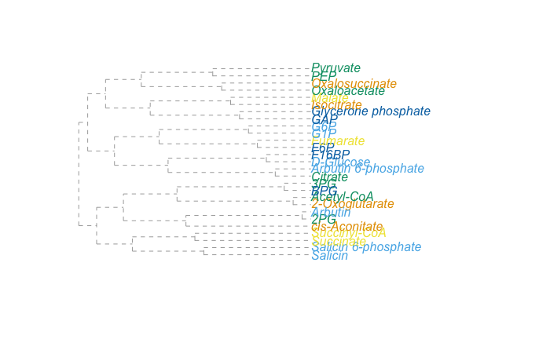

```r
# デンドログラムをプロット
plot_dendrogram(data)
```

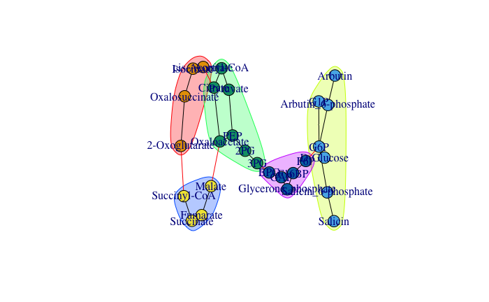

```r
# コミュニティ検出の結果
set.seed(5)
plot(data, g)
```

### 焼きなまし法に基づく方法

これはigraphではなく、rnetcartoパッケージを使います。CRANレポジトリから削除されていることがあるので、その場合は以下のようにしてソースからインストールします。これにはGNU Scientific Library (GSL)が必要です。[コミュニティ検出のREADME](https://github.com/kztakemoto/network-analysis-in-biology/tree/main/community_detection)の「準備」に従って、GSLを事前にインストールしておいてください。

```r
#2024年9月18日現在はCRANレポジトリにあるので実行しなくてよいです。
#library(devtools)
#install_github("cran/rnetcarto", INSTALL_opts=c("--no-multiarch"))
```

rnetcartoパッケージの読み込み

```r
library(rnetcarto)
```

rnetcartoによるコミュニティ検出と機能地図作成

```r
# 隣接行列を取得
mtx <- as_adjacency_matrix(g, sparse=F)
# コミュニティ抽出を実行
res <- netcarto(mtx)
# 出力結果
res
```

|  | name | module | connectivity | participation | role |
| --- | --- | --- | --- | --- | --- |
| 2 | 2PG | 0 | -1.732051e+00 | 0.5000000 | Peripheral |
| 3 | 3PG | 0 | -6.970740e-16 | 0.0000000 | Ultra peripheral |
| 7 | BPG | 0 | -6.970740e-16 | 0.0000000 | Ultra peripheral |
| 16 | Glycerone_phosphate | 0 | -6.970740e-16 | 0.0000000 | Ultra peripheral |
| 10 | F16BP | 0 | -6.970740e-16 | 0.4444444 | Peripheral |
| 15 | GAP | 0 | 1.732051e+00 | 0.0000000 | Ultra peripheral |
| 4 | Acetyl-CoA | 1 | 0.000000e+00 | 0.0000000 | Ultra peripheral |
| 22 | Pyruvate | 1 | 0.000000e+00 | 0.0000000 | Ultra peripheral |
| 8 | Citrate | 1 | 0.000000e+00 | 0.4444444 | Peripheral |
| 19 | Oxaloacetate | 1 | 0.000000e+00 | 0.4444444 | Peripheral |

[output cut: 17 more lines]

```
[[2]]
[1] 0.6141498
```

igraphの出力結果と一致するように出力を調整して、ネトワークを描画

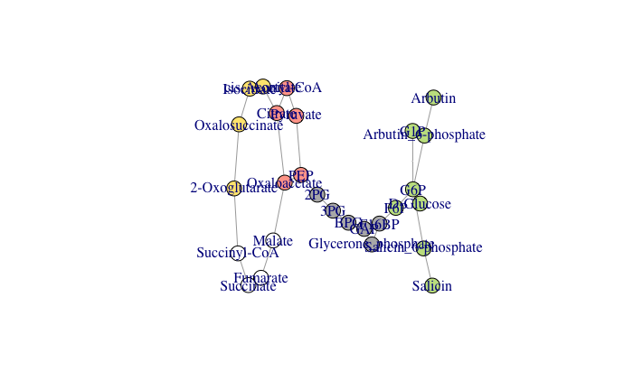

```r
# 出力の調整
table <- as.data.frame(res[[1]])
table$module <- table$module + 1
row.names(table) <- table$name
table <- table[V(g)$name,]
data <- list(membership = table$module, modularity=c(res[[2]]))
# ネットワーク描画
V(g)$community <- data$membership
colrs <- adjustcolor( c("gray50", "tomato", "gold", "yellowgreen"), alpha=.6) # 色付け
set.seed(5)
plot(g, vertex.color=colrs[V(g)$community])
```

### Functional Cartographyによるノード分類へのアクセス

```r
table$role
```

```
 [1] Peripheral       Peripheral       Ultra peripheral Ultra peripheral Ultra peripheral Ultra peripheral
 [7] Ultra peripheral Peripheral       Ultra peripheral Peripheral       Peripheral       Ultra peripheral
[13] Ultra peripheral Peripheral Hub   Ultra peripheral Ultra peripheral Ultra peripheral Peripheral
[19] Peripheral       Ultra peripheral Peripheral       Ultra peripheral Ultra peripheral Ultra peripheral
[25] Ultra peripheral Peripheral       Peripheral
7 Levels: Ultra peripheral < Peripheral < Connector < Kinless < Peripheral Hub < ... < Kinless Hub
```

### [参考] 他の方法（igraphパッケージ）

- 辺媒介性に基づくアルゴリズム `cluster_edge_betweenness(g)`（[Girvan & Newman, 2002](https://arxiv.org/abs/cond-mat/0112110)）
- ランダムウォークに基づくアルゴリズム `cluster_walktrap(g, modularity=TRUE)`（[Pons & Latapy, 2006](http://www.leonidzhukov.net/hse/2015/sna/papers/PonsLatapy2006.10.2.pdf)）
- 多段階最適化に基づくアルゴリズム `cluster_louvain(g)`（[Blondel et al., 2008](https://arxiv.org/abs/0803.0476)）
- スピングラスに基づくアルゴリズム `cluster_spinglass(g)`（[Reichardt & Bornholdt, 2006](http://www.itp.uni-bremen.de/complex/pdf/pre016110.pdf)）
- ラベル伝播法に基づくアルゴリズム `cluster_label_prop(g)`（[Raghavan et al., 2007](https://arxiv.org/abs/0709.2938)）
- Infomap法に基づくアルゴリズム `cluster_infomap(g)`（[Rosvall & Bergstorm, 2008](https://arxiv.org/abs/0707.0609)）

# やってみよう

- このNotebookを参考にして，生物ネットワークを解析してみよう（`data`に様々ある）。
- Notebookを参考に自分のデータを解析してみよう。